# Assignment 5

Xintian Li

October 25, 2019

```r
knitr::opts_chunk$set(echo = TRUE, results=TRUE, echo=TRUE, message = FALSE,
                      warning=FALSE, fig.align="center", cache=TRUE)
options(scipen=99)
```

```r
library(tidyverse)
library(caret)
library(knitr)
library(pscl)
library(plotROC)
library(pROC)

palette5 <- c("#981FAC","#CB0F8B","#FF006A","#FE4C35","#FE9900")
palette4 <- c("#981FAC","#FF006A","#FE4C35","#FE9900")
palette2 <- c("#981FAC","#FF006A")
```

```r
cr <- read.csv("D:/Upenn_Xintian/1Courses/MUSA 507/Week8/people_based_ml_hw_2019/housingSubsidy.csv")
cr <- na.omit(cr)
```

### 1.One paragraph on the motivation for the analysis.

The motivation of this cost & benefit analysis is to predict whether or not the householders will take the credit and repair their houses. If we could use machine learning method to build logistics model and precisely predict the True Positive(the people who will take the credit and the model predict them),and minimize the number of False Negative (the people who will take the credit, but the model dose not predict them), we could minimize the loss of untargeted marketing and maxmize the total benefits of both the householders and the government.

### 2.Develop and interpret data visualizations that describe feature importance.

This may provide instructions for my feature engineerings below.

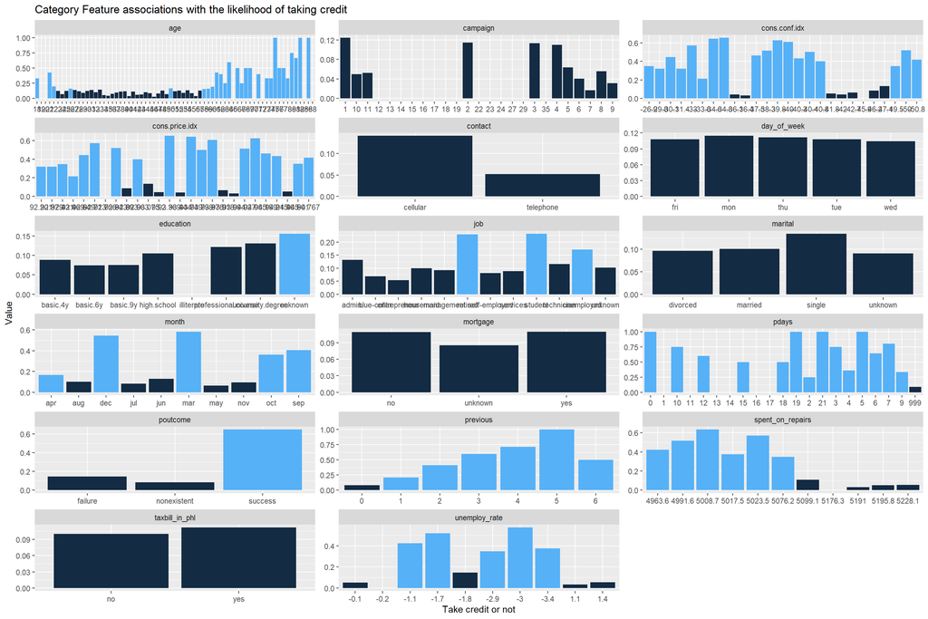

```r
cg <- cr %>%
  dplyr::select(-y_numeric,-X,-inflation_rate,-taxLien) %>%
  gather(Variable, value, -y) %>%
  count(Variable,value,y)

cgyes <- subset(cg,cg$y=="yes")
cgno <- subset(cg,cg$y=="no")
names(cgyes)[4] <- "yes"
names(cgno)[4] <- "no"
cg_new <- merge(cgno,cgyes,by=c("Variable","value"),all=T)

cg_new[is.na(cg_new)] <- 0

cg_new$percent <- cg_new$yes/(cg_new$no+cg_new$yes)
cg_new$useful <- ifelse(cg_new$percent>0.15,1,0)

cg_new %>%
  ggplot(., aes(value, percent,fill=useful)) +
  geom_bar(stat="identity") +
  facet_wrap(~Variable, scales="free",ncol=3) +
  labs(x="Take credit or not", y="Value",
       title = "Category Feature associations with the likelihood of taking credit") +
  theme(legend.position = "none")
```

### 3. Do featuring engineering and split the data into a 65/35 training/test set.

```r
# add interaction terms
cr$join_job_mari_edu <- paste(cr$job,cr$marital,cr$education,sep=",")
# add catergories for contunious variables.
cr$age_cat <- case_when(cr$age>60~"older than 60",cr$age<=23~"younger than 23",cr$age>23&cr$age<=60~"other")
cr$infla_rate_cat <-case_when(cr$inflation_rate<=0.8~"A",
                              cr$inflation_rate>0.8&cr$inflation_rate<0.85~"B",
                              cr$inflation_rate>=0.85&cr$inflation_rate<0.9~"C",
                              cr$inflation_rate>=0.9&cr$inflation_rate<1.2~"D",
                              cr$inflation_rate>=1.2&cr$inflation_rate<1.35~"E",
                              cr$inflation_rate>=1.35&cr$inflation_rate<1.4~"F",
                              cr$inflation_rate>=1.4&cr$inflation_rate<1.5~"G",
                              cr$inflation_rate>=1.5&cr$inflation_rate<2~"H",
                              cr$inflation_rate>=3&cr$inflation_rate<4~"I",
                              cr$inflation_rate>=4&cr$inflation_rate<4.2~"J",
                              cr$inflation_rate>=4.2&cr$inflation_rate<4.8~"K",
                              cr$inflation_rate>=4.8&cr$inflation_rate<4.9~"L",
                              cr$inflation_rate>=4.9&cr$inflation_rate<4.95~"M",
                              cr$inflation_rate>=4.95&cr$inflation_rate<5.5~"N")
cr$campaign_cat <- case_when(cr$campaign>11~"will say no",cr$campaign<=11~"yes or no")
cr$previous_class <- factor(ifelse(cr$previous==0,"0",
                                        ifelse(cr$previous==1,"1","Others")))
cr$unemploy_rate_class <- factor(ifelse(cr$unemploy_rate< -0.2,"1","0"))
```

Below I split the dataset into training set and test set (65:35).

```r
set.seed(3456)
trainIndex <- createDataPartition(y=paste(cr$y,cr$taxLien,cr$j_m_e,cr$age_cat,cr$inflaRa_cc,cr$camp_c,cr$edu), p = .65,
                                  list = FALSE,
                                  times = 1)
crTrain <- cr[ trainIndex,]
crTest  <- cr[-trainIndex,]
```

### 4.Engineer new features

##### a.Interpret your new features in one paragraph.

As can be seen from the explanary analysis in Chapter 2, there are many variables where in some of their categories, for example, people older than 60, the proportion of “saying yes” (that’s to say, take the credit) is obviously higher than the other categoroies. Therefore, I use the following steps to do the featuring engineering.

##### b.Show a regression summary for both the kitchen sink and your engineered regression.

First comes the regression summary for my engineered regression with a threshold of 0.21 (the threshold to get the largest revenue).

```r
Model1 <- glm(y_numeric ~ .,
              data=crTrain %>% dplyr::select(-X,-y,-dOfW,
                                             -job,-mari,-edu,-taxLien),
              family="binomial" (link="logit"))
summary(Model1)
```

```
##
## Call:
## glm(formula = y_numeric ~ ., family = binomial(link = "logit"),
##     data = crTrain %>% dplyr::select(-X, -y, -dOfW, -job, -mari,
##         -edu, -taxLien))
##
## Deviance Residuals:
##      Min        1Q    Median        3Q       Max
## -2.36821  -0.43099  -0.31051  -0.00019   3.13020
##
## Coefficients: (2 not defined because of singularities)
##                                                      Estimate
## (Intercept)                                     -150.70685345
## age                                                0.01975450
## morunknown                                         0.04656750
## moryes                                            -0.12885415
## taInPyes                                          -0.06942355
## contelephone                                      -1.08992939
## monaug                                             0.51128706
## mondec                                             1.41609560
## monjul                                             0.67150634
## monjun                                             0.89972258
## monmar                                             0.48110664
## monmay                                            -0.08305133
## monnov                                             0.14574176
## monoct                                            -0.10115494
## monsep                                             0.48073476
## camp                                              -0.03268485
## pdays                                              0.00003962
## pre                                                0.36140327
## pcomnonexistent                                    1.02651525
## pcomsuccess                                        1.80464702
## unemlpRa                                          -0.56473586
## pidx                                               1.04975113
## cidx                                               0.00087748
## inflaRa                                           -2.37090473
## spOre                                              0.00382476
## j_m_eadmin.,divorced,basic.6y                      0.83594379
## j_m_eadmin.,divorced,basic.9y                     17.51509811
## j_m_eadmin.,divorced,high.school                  16.37286917
```

[output cut: 761 more lines]

```
## inflaRa_cN                                      0.428665
## camp_cyes or no                                 0.984242
## pre_cl1                                         0.786496
## pre_clOthers                                          NA
## inflaRa_cc1                                           NA
## ---
## Signif. codes:  0 '***' 0.001 '**' 0.01 '*' 0.05 '.' 0.1 ' ' 1
##
## (Dispersion parameter for binomial family taken to be 1)
##
##     Null deviance: 2242.7  on 3005  degrees of freedom
## Residual deviance: 1578.2  on 2744  degrees of freedom
## AIC: 2102.2
##
## Number of Fisher Scoring iterations: 17
```

Confusion Matrix and Statistics of my engineered regression model.

```r
testProbs <- data.frame(Outcome = as.factor(crTest$y_numeric),
                        Probs = predict(Model1, crTest, type= "response"))
testProbs <-
  testProbs %>%
  mutate(predOutcome  = as.factor(ifelse(testProbs$Probs > 0.21, 1, 0)))

caret::confusionMatrix(testProbs$predOutcome, testProbs$Outcome,
                       positive = "1")
```

```
## Confusion Matrix and Statistics
##
##           Reference
## Prediction   0   1
##          0 955  31
##          1  77  50
##
##                Accuracy : 0.903
##                  95% CI : (0.884, 0.9197)
##     No Information Rate : 0.9272
##     P-Value [Acc > NIR] : 0.9988
##
##                   Kappa : 0.4301
##
##  Mcnemar's Test P-Value : 0.0000149
##
##             Sensitivity : 0.61728
##             Specificity : 0.92539
##          Pos Pred Value : 0.39370
##          Neg Pred Value : 0.96856
##              Prevalence : 0.07278
##          Detection Rate : 0.04492
##    Detection Prevalence : 0.11411
##       Balanced Accuracy : 0.77134
##
##        'Positive' Class : 1
##
```

```r
#McFadden R Square
pR2(Model1)
```

```
##           llh       llhNull            G2      McFadden          r2ML
##  -789.1019098 -1121.3316194   664.4594192     0.2962814     0.1983189
##          r2CU
##     0.3771973
```

Below is the kitchen sink model with a threshold of 0.5.

```r
cr_o <- read.csv("D:/Upenn_Xintian/1Courses/MUSA 507/Week8/people_based_ml_hw_2019/housingSubsidy.csv")
set.seed(3456)
trainIndex_o <- createDataPartition(y=paste(cr_o$y), p = .65,
                                  list = FALSE,
                                  times = 1)
crTrain_o <- cr_o[ trainIndex,]
crTest_o  <- cr_o[-trainIndex,]
Model <- glm(y_numeric ~ .,
              data=crTrain_o %>% dplyr::select(-X,-y,-taxLien),
              family="binomial" (link="logit"))
summary(Model)
```

```
##
## Call:
## glm(formula = y_numeric ~ ., family = binomial(link = "logit"),
##     data = crTrain_o %>% dplyr::select(-X, -y, -taxLien))
##
## Deviance Residuals:
##     Min       1Q   Median       3Q      Max
## -1.9590  -0.4423  -0.3489  -0.2672   2.7178
##
## Coefficients:
##                                  Estimate   Std. Error z value  Pr(>|z|)
## (Intercept)                  -186.8357647  113.0847317  -1.652   0.09850
## age                             0.0142253    0.0072540   1.961   0.04988
## jobblue-collar                 -0.2834566    0.2339179  -1.212   0.22560
## jobentrepreneur                -0.5953659    0.4020427  -1.481   0.13865
## jobhousemaid                   -0.2050133    0.4022700  -0.510   0.61030
## jobmanagement                  -0.4831906    0.2630666  -1.837   0.06625
## jobretired                     -0.2514616    0.3085439  -0.815   0.41508
## jobself-employed               -0.6158297    0.3643826  -1.690   0.09102
## jobservices                    -0.1838805    0.2473352  -0.743   0.45721
## jobstudent                     -0.1368583    0.3616869  -0.378   0.70514
## jobtechnician                  -0.0610664    0.2053364  -0.297   0.76616
## jobunemployed                   0.0232998    0.3395099   0.069   0.94529
## jobunknown                     -0.6433697    0.6437146  -0.999   0.31757
## maritalmarried                  0.1658481    0.2042018   0.812   0.41669
## maritalsingle                   0.2588551    0.2371856   1.091   0.27511
## maritalunknown                 -0.0933837    1.1764672  -0.079   0.93673
## educationbasic.6y               0.2216770    0.3469297   0.639   0.52284
## educationbasic.9y               0.0868593    0.2835647   0.306   0.75937
## educationhigh.school            0.1505846    0.2674766   0.563   0.57345
## educationilliterate           -11.0573316  324.7440520  -0.034   0.97284
## educationprofessional.course    0.1852874    0.2924757   0.634   0.52640
## educationuniversity.degree      0.2300094    0.2691280   0.855   0.39275
## educationunknown                0.1995269    0.3480406   0.573   0.56645
## mortgageunknown                -0.3156603    0.4543962  -0.695   0.48726
## mortgageyes                    -0.1571694    0.1246168  -1.261   0.20723
## taxbill_in_phlyes               0.0283817    0.1688480   0.168   0.86651
## contacttelephone               -1.0018877    0.2529701  -3.960 0.0000748
## monthaug                        0.1320086    0.3791876   0.348   0.72774
## monthdec                        1.2489703    0.6541845   1.909   0.05624
```

[output cut: 67 more lines]

```
## unemploy_rate                *
## cons.price.idx               *
## cons.conf.idx                .
## inflation_rate
## spent_on_repairs
## ---
## Signif. codes:  0 '***' 0.001 '**' 0.01 '*' 0.05 '.' 0.1 ' ' 1
##
## (Dispersion parameter for binomial family taken to be 1)
##
##     Null deviance: 2449.6  on 3226  degrees of freedom
## Residual deviance: 1921.7  on 3177  degrees of freedom
## AIC: 2021.7
##
## Number of Fisher Scoring iterations: 11
```

Confusion Matrix and Statistics of kitchen sink model.

```r
testProbs_sink <- data.frame(Outcome = as.factor(crTest_o$y_numeric),
                        Probs = predict(Model, crTest_o, type= "response"))
testProbs_sink <-
  testProbs_sink %>%
  mutate(predOutcome  = as.factor(ifelse(testProbs_sink$Probs > 0.5, 1, 0)))

caret::confusionMatrix(testProbs_sink$predOutcome, testProbs_sink$Outcome,
                       positive = "1")
```

```
## Confusion Matrix and Statistics
##
##           Reference
## Prediction   0   1
##          0 838  33
##          1  11  10
##
##                Accuracy : 0.9507
##                  95% CI : (0.9343, 0.9639)
##     No Information Rate : 0.9518
##     P-Value [Acc > NIR] : 0.601275
##
##                   Kappa : 0.29
##
##  Mcnemar's Test P-Value : 0.001546
##
##             Sensitivity : 0.23256
##             Specificity : 0.98704
##          Pos Pred Value : 0.47619
##          Neg Pred Value : 0.96211
##              Prevalence : 0.04821
##          Detection Rate : 0.01121
##    Detection Prevalence : 0.02354
##       Balanced Accuracy : 0.60980
##
##        'Positive' Class : 1
##
```

```r
#McFadden R Square
pR2(Model)
```

```
##           llh       llhNull            G2      McFadden          r2ML
##  -960.8402471 -1224.8069411   527.9333881     0.2155170     0.1509174
##          r2CU
##     0.2837262
```

##### c.Cross validate both models and show two facetted plots of ROC, Sensitivtity and Specificity.

- Cross validation of my engineered model

```r
ctrl <- trainControl(method = "cv", number = 100, classProbs=TRUE, summaryFunction=twoClassSummary)

cvFit <- train(y ~ ., data = cr%>% dplyr::select(-X,-y_numeric,-day_of_week,
                                             -job,-marital,-education,-taxLien),
                method="glm", family="binomial",
                metric="ROC", trControl = ctrl)

cvFit
```

```
## Generalized Linear Model
##
## 4119 samples
##   20 predictor
##    2 classes: 'no', 'yes'
##
## No pre-processing
## Resampling: Cross-Validated (100 fold)
## Summary of sample sizes: 4077, 4078, 4077, 4077, 4077, 4078, ...
## Resampling results:
##
##   ROC       Sens       Spec
##   0.730387  0.9702703  0.2355
```

- Cross validation of the kitchen sink model

```r
ctrl_o <- trainControl(method = "cv", number = 100, classProbs=TRUE, summaryFunction=twoClassSummary)

cvFit_o <- train(y ~ ., data = cr_o%>% dplyr::select(-X,-y_numeric,-taxLien),
                method="glm", family="binomial",
                metric="ROC", trControl = ctrl)

cvFit_o
```

```
## Generalized Linear Model
##
## 4119 samples
##   18 predictor
##    2 classes: 'no', 'yes'
##
## No pre-processing
## Resampling: Cross-Validated (100 fold)
## Summary of sample sizes: 4077, 4077, 4077, 4077, 4079, 4077, ...
## Resampling results:
##
##   ROC        Sens       Spec
##   0.7653679  0.9803529  0.223
```

- Two facetted plots of ROC, Sensitivtity and Specificity.

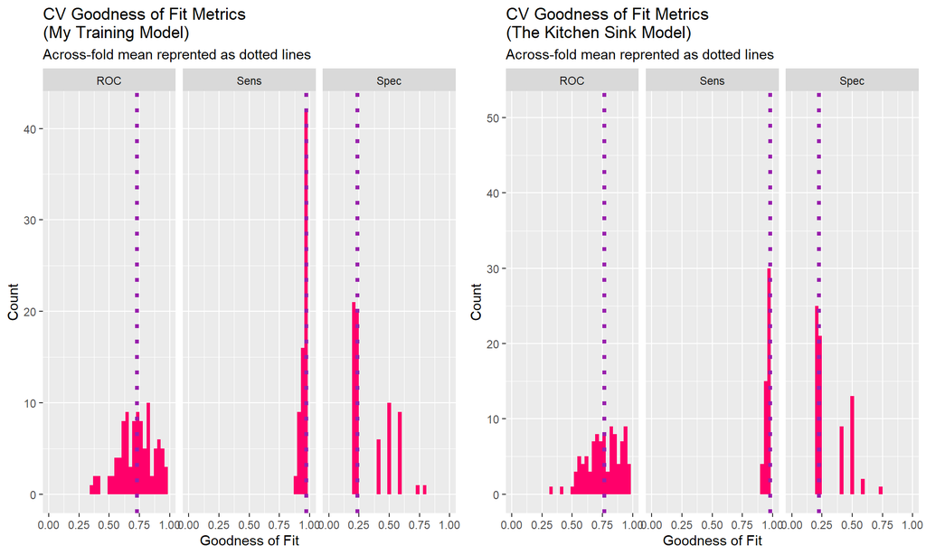

```r
plot <- dplyr::select(cvFit$resample, -Resample) %>%
  gather(metric, value) %>%
  left_join(gather(cvFit$results[2:4], metric, mean)) %>%
  ggplot(aes(value)) +
    geom_histogram(bins=35, fill = "#FF006A") +
    facet_wrap(~metric) +
    geom_vline(aes(xintercept = mean), colour = "#981FAC", linetype = 3, size = 1.5) +
    scale_x_continuous(limits = c(0, 1)) +
    labs(x="Goodness of Fit", y="Count", title="CV Goodness of Fit Metrics \n(My Training Model)",
         subtitle = "Across-fold mean reprented as dotted lines")

plot1 <- dplyr::select(cvFit_o$resample, -Resample) %>%
  gather(metric, value) %>%
  left_join(gather(cvFit_o$results[2:4], metric, mean)) %>%
  ggplot(aes(value)) +
    geom_histogram(bins=35, fill = "#FF006A") +
    facet_wrap(~metric) +
    geom_vline(aes(xintercept = mean), colour = "#981FAC", linetype = 3, size = 1.5) +
    scale_x_continuous(limits = c(0, 1)) +
    labs(x="Goodness of Fit", y="Count", title="CV Goodness of Fit Metrics \n(The Kitchen Sink Model)",
         subtitle = "Across-fold mean reprented as dotted lines")
library(gridExtra)
grid.arrange(plot,plot1,ncol=2)
```

### 5.Output an ROC curve and interpret it.

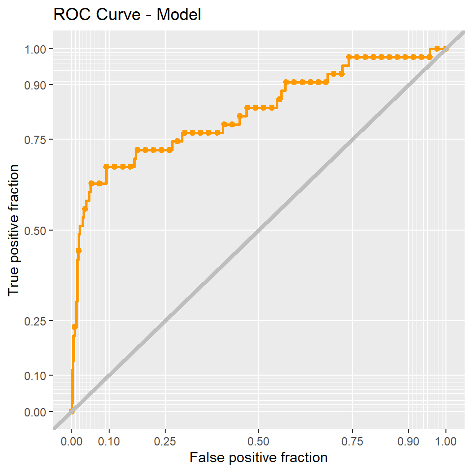

```r
ggplot(testProbs, aes(d = as.numeric(testProbs$Outcome), m = Probs)) +
  geom_roc(n.cuts = 50, labels = FALSE, colour = "#FE9900") +
  style_roc(theme = theme_grey) +
  geom_abline(slope = 1, intercept = 0, size = 1.5, color = 'grey') +
  labs(title = "ROC Curve - Model")
```

```r
auc(testProbs$Outcome, testProbs$Probs)
```

```
## Area under the curve: 0.823
```

As can be seen from the ROC curve above, my trained model is much better than the coin flip model(50%). It is not overfitted as well. Every point on the ROC curve represents a specific threshold. Make parallel lines to x axis and y axis and we can get the true positive fraction and false positive fraction at that threshold.

### 6.Develop a cost benefit analysis.

##### a.Fill out the ‘fill in the blank’ confusion metric description.

```
* (1)True Positive: For 80%, -$2850 for marketing - $5000 for the credit + $10000 + $56000 for the house/neighborhood benefit. For 20%, -$2850 for marketing.
* (2)True Negative: $0
* (3)False Positive: -$2850 for marketing
* (4)False Negative: $0
```

##### b.Create the ‘Cost/Benefit Table’.

```r
cost_benefit_table <-
   testProbs %>%
      count(predOutcome, Outcome) %>%
      summarize(True_Negative = sum(n[predOutcome==0 & Outcome==0]),
                True_Positive = sum(n[predOutcome==1 & Outcome==1]),
                False_Negative = sum(n[predOutcome==0 & Outcome==1]),
                False_Positive = sum(n[predOutcome==1 & Outcome==0])) %>%
       gather(Variable, Count) %>%
       mutate(Revenue =
               ifelse(Variable == "True_Positive", (66000-2850-5000)*(Count * 0.8)-2850*(Count * 0.2),
               ifelse(Variable == "True_Negative",Count*0,
               ifelse(Variable == "False_Positive", (-2850) * Count,
               ifelse(Variable == "False_Negative", 0 * Count, 0))))) %>%
    bind_cols(data.frame(Description = c(
              "We predicted no churn and we didn't send a mailer",
              "We predicted churn and sent the mailer",
              "We predicted no churn and customer churned",
              "We predicted churn and customer did not churn")))
library(kableExtra)
kable(cost_benefit_table,
       caption = "Cost/Benefit Table") %>% kable_styling()
```

Cost/Benefit Table

[output not shown]

##### c.Plot the confusion metric outcomes for each Threshold.

It can be concluded from the plots below that we should find a threshold to maximam our total benefits.

```r
iterateThresholds <- function(data) {
  x = .01
  all_prediction <- data.frame()
  while (x <= 1) {

  this_prediction <-
      testProbs %>%
      mutate(predOutcome = ifelse(Probs > x, 1, 0)) %>%
      count(predOutcome, Outcome) %>%
      summarize(True_Negative = sum(n[predOutcome==0 & Outcome==0]),
                True_Positive = sum(n[predOutcome==1 & Outcome==1]),
                False_Negative = sum(n[predOutcome==0 & Outcome==1]),
                False_Positive = sum(n[predOutcome==1 & Outcome==0])) %>%
     gather(Variable, Count) %>%
     mutate(Revenue =
               ifelse(Variable == "True_Negative", Count * 0,
               ifelse(Variable == "True_Positive",(66000-2850-5000)*(Count * 0.8)-2850*(Count * 0.2),
               ifelse(Variable == "False_Negative", 0 * Count,
               ifelse(Variable == "False_Positive", (-2850) * Count,0)))),
            Threshold = x)

  all_prediction <- rbind(all_prediction, this_prediction)
  x <- x + .01
  }
return(all_prediction)
}
```

```r
whichThreshold <- iterateThresholds(testProbs)
```

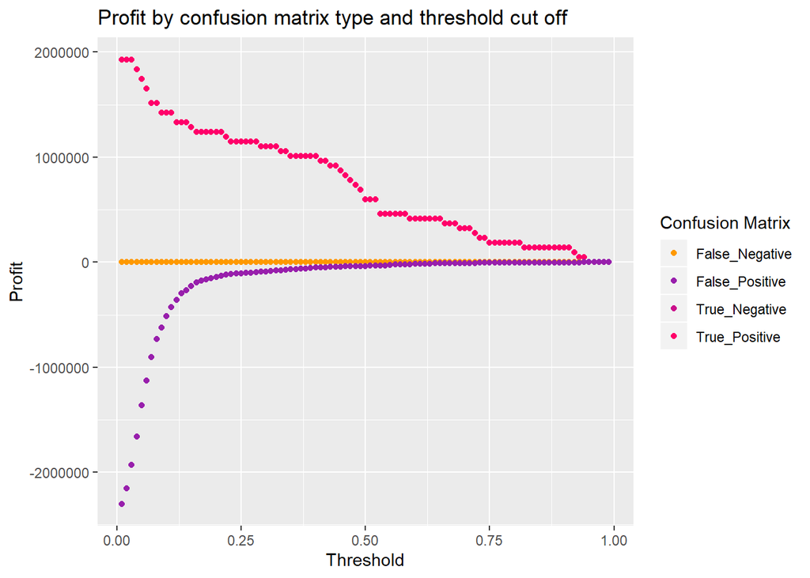

```r
whichThreshold %>%
  ggplot(.,aes(Threshold, Revenue, colour = Variable)) +
  geom_point() +
  scale_colour_manual(values = palette5[c(5, 1:6)]) +
  labs(title = "Profit by confusion matrix type and threshold cut off",
       y="Profit") +
  guides(colour=guide_legend(title="Confusion Matrix"))
```